# Assignment 1 - Vis

Aron Lesser

9/9/2020

# Loading Data

Loading area-level data from the 2000 census

```r
area_vars_2000 <- load_variables(2000, "sf3" )
```

Loading area-level data from the 2010 census

```r
area_vars_2010 <- load_variables(2010, "sf1")
```

I was surprised to learn that the 2000 sf3 has more variables than the 2010 sf1. I ultimately chose the 2010 decennial census data because it is more recent and may better reflect the types of trends that interest me.

# Selecting Variables

My variables are:

1. Majority home owners or renters (categorical)
2. Urban or Rural (categorical)
3. Average household size (continuous)
4. Percentage of households that contain 6 people (continuous)
5. Median age(continuous)
6. Percentage of renters (continuous)

# Data Wrangling

Below, I had to do some mutations in order to get the percentage of renters in a tract, whether it was majority owner or renter, and if it was urban or rural. I chose a county in Georgia that I knew had some rural zones.

```r
vars <- c(total_urban = "H002002",
          total_hh = "H001001",
          avg_hh_size = "P017001",
          tot_6p_hh = "H013007",
          tot_hh_size = "H013001",
          tot_renteroccupied = "H004004",
         tot_ownedmortg = "H004002",
         tot_ownedclear = "H004003",
         tot_tenure = "H004001",
         med_age = "P013001")

C_tracts <- get_decennial(geography = "tract", variables = vars,
                           state = "GA", county = "Fulton",
                           output = "wide",
                           year = 2010,
                           survey = "asf1") %>%

  mutate(pct_6ph = tot_6p_hh / tot_hh_size,
           pct_renteroccupied = tot_renteroccupied / tot_tenure,
         urban = (total_hh == total_urban),
          majority_owner = (tot_ownedmortg + tot_ownedclear) / tot_tenure > 0.5) %>%
  filter(avg_hh_size > 0) %>%
select(avg_hh_size, pct_6ph, med_age, pct_renteroccupied, majority_owner, urban)
```

```
## Using Census Summary File 1
```

# Plotting My Variables

### 1. Average Household Size and Percent of Households in Rented Homes

In this scatterplot, I did not have a regression line in my first attempt and was having trouble identifying a trend. Adding the linear regression helped me to identify the trend. The tufte theme works well for this.

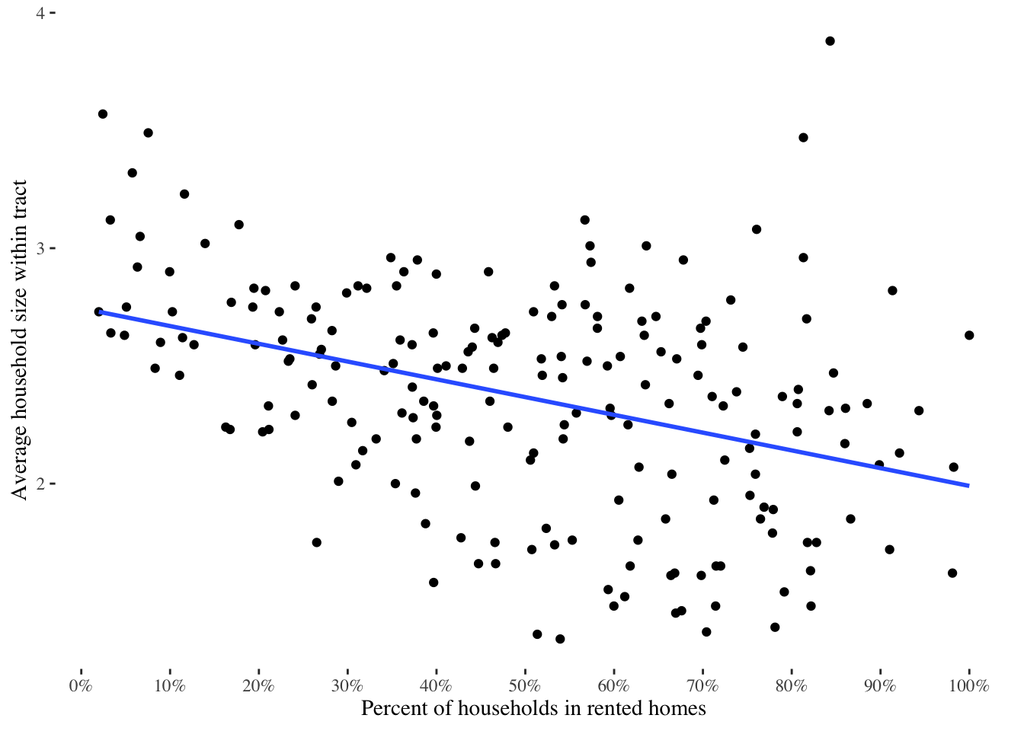

```r
ggplot(C_tracts,
       aes(x = pct_renteroccupied,
           y = avg_hh_size)) +
  geom_point() +
  geom_smooth(method="lm", se=F) +
  scale_x_continuous(name = "Percent of households in rented homes",
                     breaks = seq(0, 1, by = 0.1),
                     labels = paste(seq(0, 100, by = 10), "%", sep = "")) +
  scale_y_continuous(name = "Average household size within tract",
                     breaks = seq(1, 5, by = 1)) +
  theme_tufte() +
  theme(legend.key.size = unit(0.1, "cm"))
```

### 2. Average Household Size and Percent of Households in Rented Homes with Urban

Here I play around with color and remove the regression line. It does not tell a very compelling story, though it begins to become clear that rural tracts tend to ones with fewer renters. It also shows that Rural tracts have an average household size that is greater than 2.

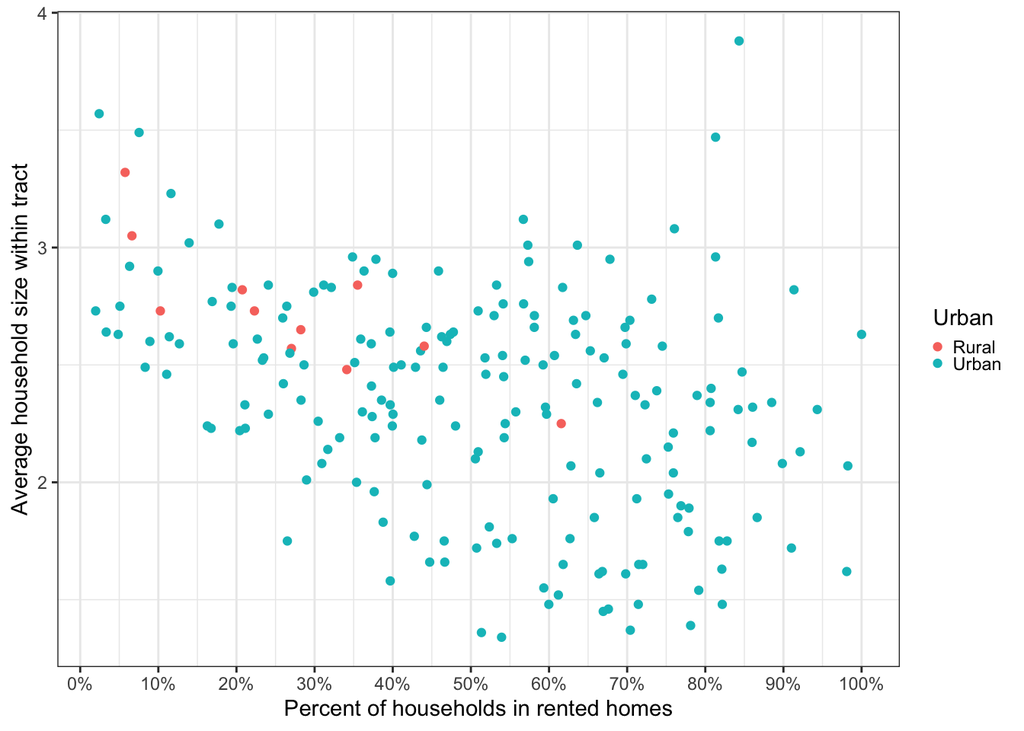

```r
ggplot(C_tracts,
       aes(x = pct_renteroccupied,
           y = avg_hh_size,
           color = urban,)) +
  geom_point() +
  scale_x_continuous(name = "Percent of households in rented homes",
                     breaks = seq(0, 1, by = 0.1),
                     labels = paste(seq(0, 100, by = 10), "%", sep = "")) +
  scale_y_continuous(name = "Average household size within tract",
                     breaks = seq(1, 7, by = 1)) +
  scale_color_discrete(name = "Urban",
                       labels = c("Rural",
                                  "Urban")) +
  theme_bw() +
  theme(legend.key.size = unit(0.1, "cm"))
```

### 3. Median Age and Percentage of 6p Households

Here, we see in this poorly visualized scatterplot that rural tracts have similar percentages of households with 6 people or more. It is hard to understand the other data represented, other than perhaps the fact that rural tracts have a smaller spread of median age than urban ones.

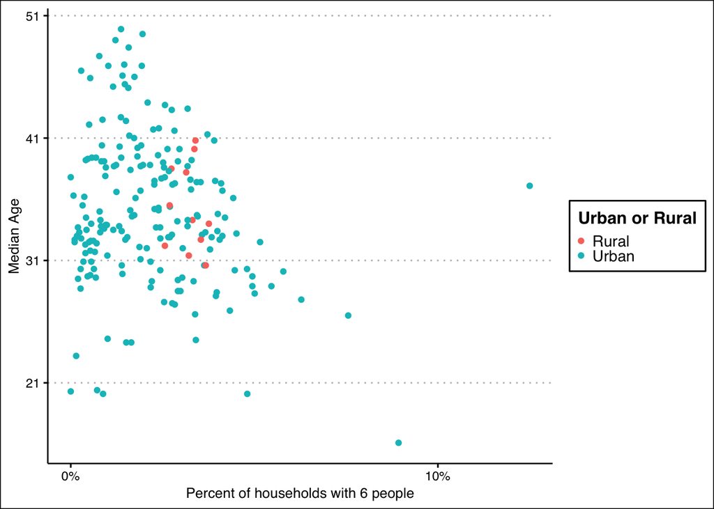

```r
ggplot(C_tracts,
       aes(x = pct_6ph,
           y = med_age,
           color = urban,)) +
  geom_point() +
  scale_x_continuous(name = "Percent of households with 6 people",
                     breaks = seq(0, 1, by = 0.1),
                     labels = paste(seq(0, 100, by = 10), "%", sep = "")) +
  scale_y_continuous(name = "Median Age",
                     breaks = seq(1, 100, by = 10)) +
  scale_color_discrete(name = "Urban or Rural",
                       labels = c("Rural",
                                  "Urban")) +
  theme_clean() +
  theme(legend.key.size = unit(0.1, "cm"))
```

### 4. Median age and Majority Owner

In this plot, we begin to see that renters tend to be younger, or that younger people tend to be renters. I do not want to make assumptions about causality…

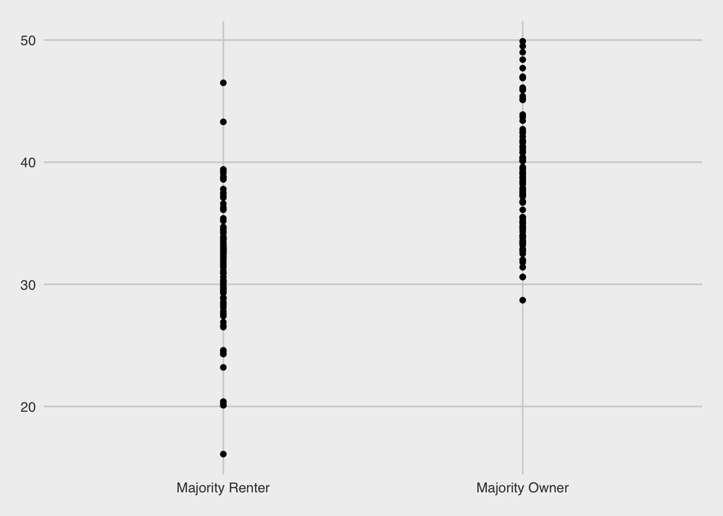

```r
ggplot(C_tracts,
       aes(x = majority_owner,
           y = med_age)) +
  geom_point() +
  scale_x_discrete(name = "Majority Tenure",
                       labels = c("Majority Renter",
                                  "Majority Owner")) +
  scale_y_continuous(name = "Median age within tract",
                     breaks = seq(10, 100, by = 10)) +
  theme_fivethirtyeight()
```

### 5. Median age and Majority Owner Boxplot

I found the boxplot to better represent the renter and age data. It visually shows those differences. I understand that not everyone knows how to interpret it.

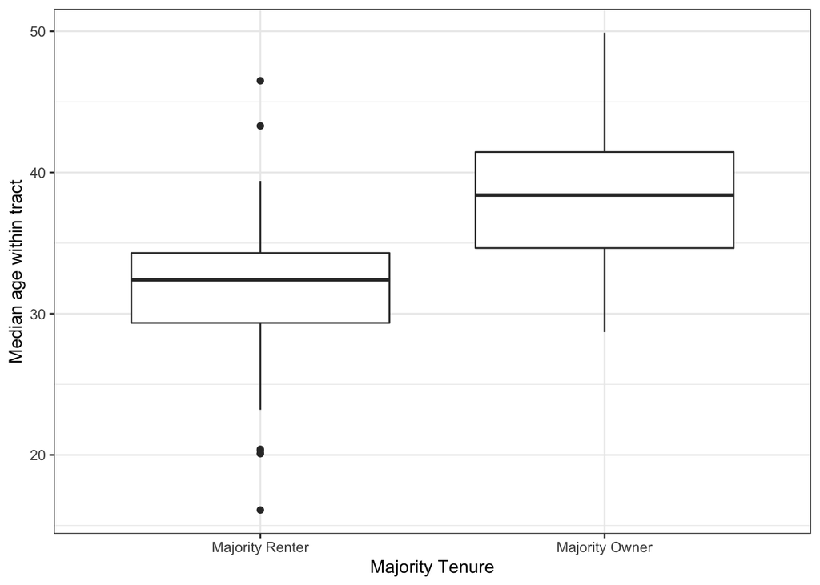

```r
ggplot(C_tracts,
       aes(x = majority_owner,
           y = med_age)) +
  geom_boxplot() +
  scale_x_discrete(name = "Majority Tenure",
                       labels = c("Majority Renter",
                                  "Majority Owner")) +
  scale_y_continuous(name = "Median age within tract",
                     breaks = seq(10, 100, by = 10)) +
  theme_bw()
```

### 6. Median Age and Urban or Rural Tracts Boxplot

This boxplot shows differences in the sample size, which is not necessarily that helpful. It actually obscures the slight differences between rural and urban tracts, especially for someone that does not know how to interpret the plot.

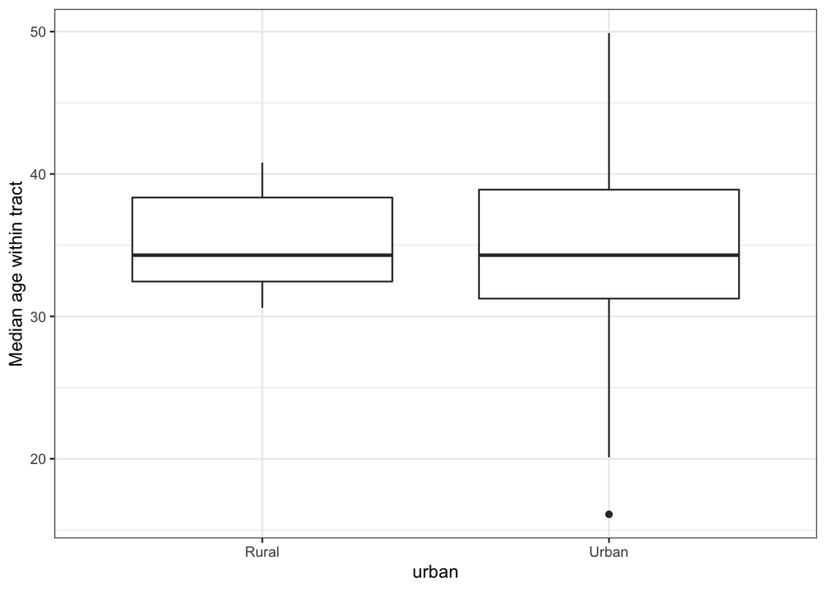

```r
ggplot(C_tracts,
       aes(x = urban,
           y = med_age)) +
  geom_boxplot() +
  scale_x_discrete(name = "urban",
                       labels = c("Rural",
                                  "Urban")) +
  scale_y_continuous(name = "Median age within tract",
                     breaks = seq(10, 100, by = 10)) +
  theme_bw()
```

### 7. Bar Graph Urban and Majority Owner

This simple bar graph demonstrates that majority owner tracts in this case have more rural tracts. It also shows how few total rural tracts are in the county.

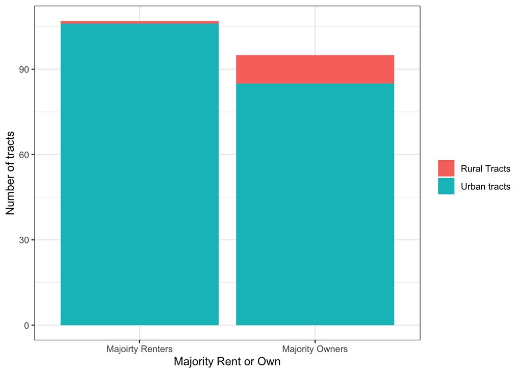

```r
ggplot(C_tracts, aes(x = majority_owner, fill = urban)) +
  geom_bar() +
  scale_y_continuous(name = "Number of tracts") +
  scale_x_discrete(name = "Majority Rent or Own",
                       labels = c("Majoirty Renters",
                                  "Majority Owners" )) +
  scale_fill_discrete(name = element_blank(),
                        labels = c("Rural Tracts",
                                   "Urban tracts")) +
  theme_bw()
```

### 8. Percentage of Renters and Median Age Scatter

This scatter plot might actually be useful, finding a trend between median age and percentage of renters in tracks.

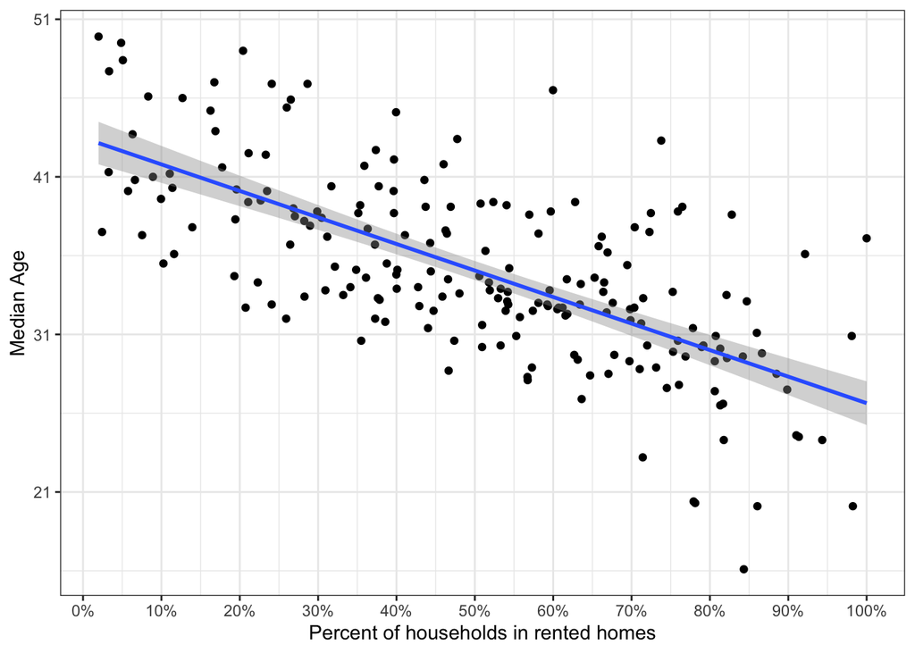

```r
ggplot(C_tracts,
       aes(x = pct_renteroccupied,
           y = med_age)) +
  geom_point() +
  stat_smooth(method = "lm") +
  scale_x_continuous(name = "Percent of households in rented homes",
                     breaks = seq(0, 1, by = 0.1),
                     labels = paste(seq(0, 100, by = 10), "%", sep = "")) +
  scale_y_continuous(name = "Median Age",
                     breaks = seq(1, 80, by = 10)) +
  theme_bw() +
  theme(legend.key.size = unit(0.1, "cm"))
```

### 9. Violin of Median age and percentage of households that contain 6 people by Tenure Composition

This unusual violin plot is hard to read.

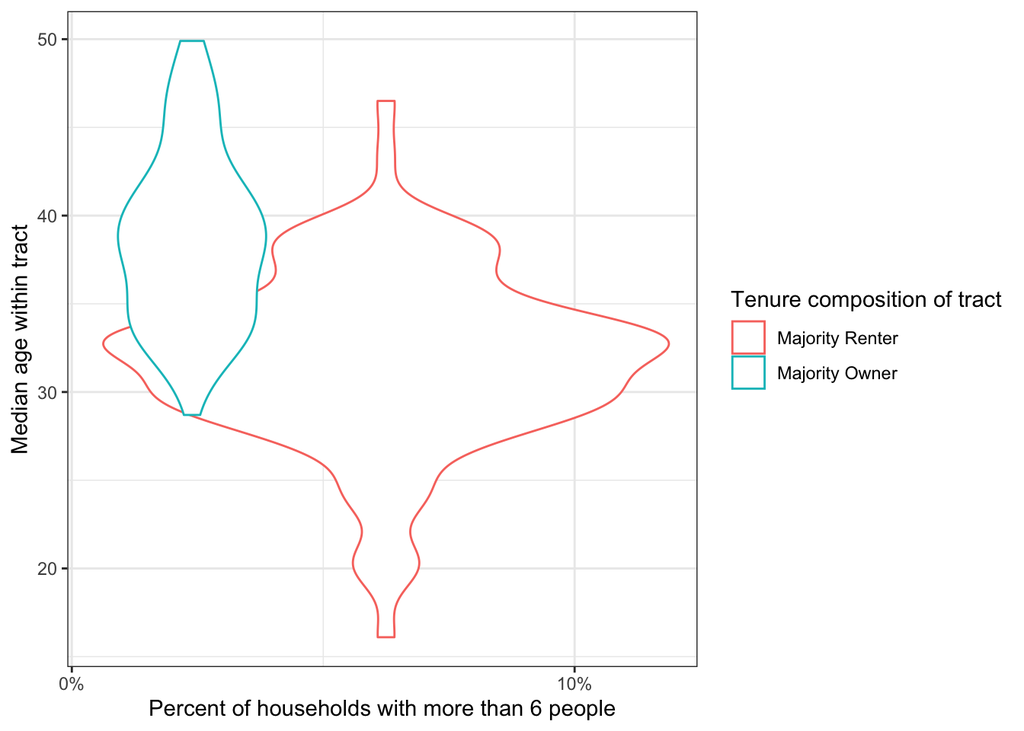

```r
ggplot(C_tracts,
       aes(x = pct_6ph,
           y = med_age,
           color = majority_owner)) +
  geom_violin() +
  scale_x_continuous(name = "Percent of households with more than 6 people",
                     breaks = seq(0, 1, by = 0.1),
                     labels = paste(seq(0, 100, by = 10), "%", sep = "")) +
  scale_y_continuous(name = "Median age within tract",
                     breaks = seq(10, 80, by = 10)) +
  scale_color_discrete(name = "Tenure composition of tract",
                       labels = c("Majority Renter",
                                  "Majority Owner")) +
  theme_bw()
```

### 10. Boxplot of Median age and percentage of households that contain 6 people by Tenure Composition

It seems that adding too many variables to this boxplot makes it not work.

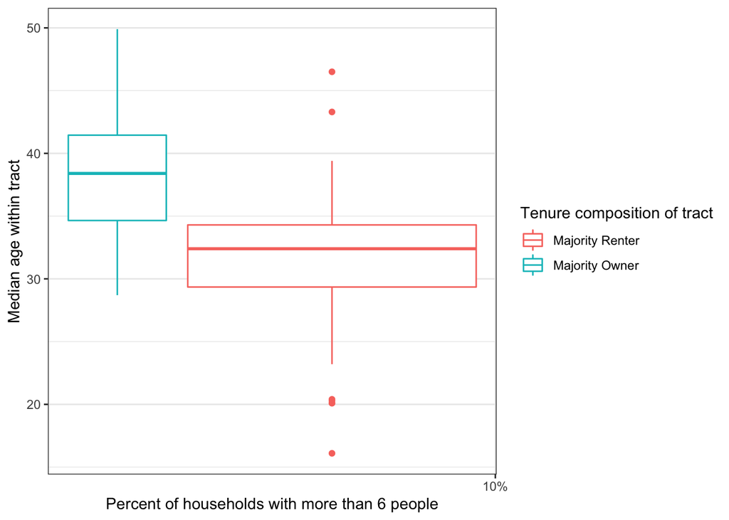

```r
ggplot(C_tracts,
       aes(x = pct_6ph,
           y = med_age,
           color = majority_owner)) +
  geom_boxplot() +
  scale_x_continuous(name = "Percent of households with more than 6 people",
                     breaks = seq(0, 1, by = 0.1),
                     labels = paste(seq(0, 100, by = 10), "%", sep = "")) +
  scale_y_continuous(name = "Median age within tract",
                     breaks = seq(10, 80, by = 10)) +
  scale_color_discrete(name = "Tenure composition of tract",
                       labels = c("Majority Renter",
                                  "Majority Owner")) +
  theme_bw() +
  theme(legend.position = "right")
```

### 11 Tenure Composition and Average Household Size

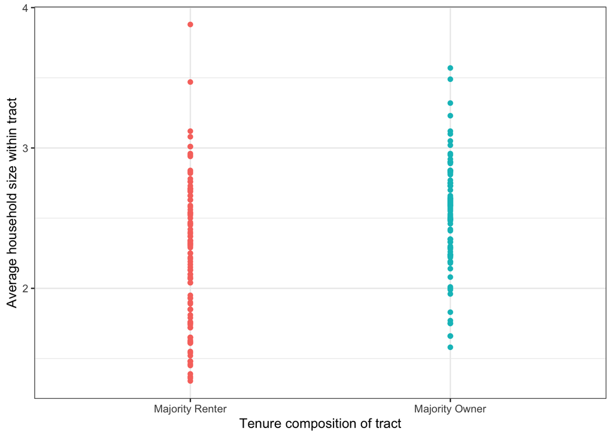

```r
ggplot(C_tracts,
       aes(x = majority_owner,
           y = avg_hh_size,
           color = majority_owner)) +
  geom_point() +
  scale_x_discrete(name = "Tenure composition of tract",
                       labels = c("Majority Renter",
                                  "Majority Owner")) +
  scale_y_continuous(name = "Average household size within tract",
                     breaks = seq(1, 8, by = 1)) +
  theme_bw() +
  theme(legend.position = "none")
```

### 12 Tenure Composition and Average Household Size with “Jitter” and Urban

Finally, this plot does in some way help to visualize the fact that most rural tracts are majority owner ones as well. In this case, the jitter and alternative coloring scheme helps.

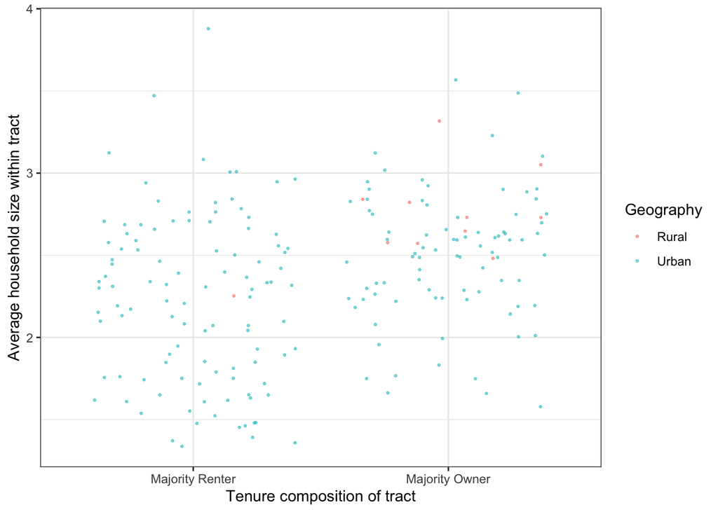

```r
ggplot(C_tracts,
       aes(x = majority_owner,
           y = avg_hh_size,
           color = urban)) +
  geom_point(position = "jitter",
             size = 0.5,
             alpha = 0.5) +
  scale_x_discrete(name = "Tenure composition of tract",
                       labels = c("Majority Renter",
                                  "Majority Owner")) +
  scale_y_continuous(name = "Average household size within tract",
                     breaks = seq(1, 8, by = 1)) +
  scale_color_discrete(name="Geography", labels=c("Rural", "Urban")) +
  theme_bw()
```

# Lessons Learned

Overall, this exercise helped me to develop some technical skills with visualization. It also taught me the importance of data cleaning earlier on and the biases involved in those decisions. It was interesting to see that changing the method of visualization helped me to analyze the same dataset and variables differently. In some ways, I imagined the process to be first analyze and then visualize. Now, I see it as more iterative. As a next step, I would like to explore a bit more how trend lines and other trend visualizations are used, particularly when representing geographic or demographic data.